# Open Data Challenge

Sister Analyst

25/03/2020

## Introduction

We will create a data analysis report about air pollution in Belgrade with the explanation of the R code used. Data that will be used for the analysis comes from the stations, which are set up by an independent initiative [Vazduh Gradjanima](https://vazduhgradjanima.rs) and is available from their [GitHub repository](https://github.com/DesconBelgrade/VazduhGradjanima/tree/master/files). The report will be created as an [R Markdown](https://rmarkdown.rstudio.com) file that can be hosted on [Netlify](https://www.netlify.com).

We will start our workshop by installing [R](https://r-project.org) and [RStudio](https://www.rstudio.com), by following the instructions available on this link: [Install R i RStudia](https://instalirajr.netlify.app).

To learn how to use [R](https://cran.r-project.org/) and develop a report like this visit [Data Challenge Platform](https://datachallengewithr.rbind.io) with learning material developed in partnership with [UNDP Serbia](http://www.rs.undp.org). In particular we will focus on matirijal [Day 1](https://datachallengewithr.rbind.io/day1/) and [Day 2](https://datachallengewithr.rbind.io/day2/).

After we get familiar with the basic R syntax and data wrangling using data available from the open data portal Republic of Serbia https://data.gov.rs/sr/, we can dig into the air pollution data set following the instructions given below.

## Airpolution case study

### Reading and organising data

We will start the analysis by uploading the necessary packages and data into R.

If you have not got the packages used in the following code, you will need to uncomment the first few lines (delete the `#` symbol) in the code below.

It is always a good idea to have a look at data you upload, before you start using it for your analysis.

```
## Rows: 29,426
## Columns: 11
## $ timestamp    <chr> "2019-10-13T14:00:00Z", "2019-10-13T15:00:00Z", "2019-10-…
## $ device_id    <chr> "qr0Kde0VpQOQLCQNrFyIZWfy", "qr0Kde0VpQOQLCQNrFyIZWfy", "…
## $ device_title <chr> "Klimerko Krunska", "Klimerko Krunska", "Klimerko Krunska…
## $ location     <chr> "44.80868072883205,20.465567163036557", "44.8086807288320…
## $ pm10         <dbl> 20.5, 13.5, 22.0, 25.5, 34.0, 33.5, 31.5, 50.0, 51.5, 43.…
## $ humidity     <dbl> 30.62500, 33.50000, 37.45000, 41.15000, 44.07500, 44.8750…
## $ pm1          <dbl> 13.0, 11.0, 15.5, 20.5, 22.0, 23.0, 22.0, 31.0, 32.0, 27.…
## $ pm2.5        <dbl> 17.0, 11.5, 19.0, 25.5, 31.0, 32.0, 30.0, 41.0, 44.0, 38.…
## $ pressure     <dbl> 1006.000, 1006.000, 1006.000, 1006.750, 1007.000, 1007.00…
## $ temperature  <dbl> 29.100, 28.025, 26.325, 25.000, 23.950, 23.475, 22.750, 2…
## $ uv.index     <dbl> NA, NA, NA, NA, NA, NA, NA, NA, NA, NA, NA, NA, NA, NA, N…
```

We can do some tweaking, by removing a few variables and separating day from time and creating separate columns for latitude and longitude variables.

```
## Rows: 29,426
## Columns: 11
## $ date         <chr> "2019-10-13", "2019-10-13", "2019-10-13", "2019-10-13", "…
## $ time         <chr> "14:00:00", "15:00:00", "16:00:00", "17:00:00", "18:00:00…
## $ device_title <chr> "Klimerko Krunska", "Klimerko Krunska", "Klimerko Krunska…
## $ lat          <chr> "44.80868072883205", "44.80868072883205", "44.80868072883…
## $ lng          <chr> "20.465567163036557", "20.465567163036557", "20.465567163…
## $ pm10         <dbl> 20.5, 13.5, 22.0, 25.5, 34.0, 33.5, 31.5, 50.0, 51.5, 43.…
## $ humidity     <dbl> 30.62500, 33.50000, 37.45000, 41.15000, 44.07500, 44.8750…
## $ pm1          <dbl> 13.0, 11.0, 15.5, 20.5, 22.0, 23.0, 22.0, 31.0, 32.0, 27.…
## $ pm2.5        <dbl> 17.0, 11.5, 19.0, 25.5, 31.0, 32.0, 30.0, 41.0, 44.0, 38.…
## $ pressure     <dbl> 1006.000, 1006.000, 1006.000, 1006.750, 1007.000, 1007.00…
## $ temperature  <dbl> 29.100, 28.025, 26.325, 25.000, 23.950, 23.475, 22.750, 2…
```

We will check how many unique records each variable in our data has.

```
##         date         time device_title          lat          lng         pm10
##           93           24           26           26           26         3403
##     humidity          pm1        pm2.5     pressure  temperature
##         7572         2853         3245         1949         5291
```

To us it is most interesting to notice that we have `uniq[[3]] = 26` stations in total. Next, we’ll check if all of the stations are active, by examining the number of readings for each station.

|  | device_title | no_readings |
| --- | --- | --- |
| 1 | Descon Klimerko Uciteljsko Naselje | 1 |
| 2 | Descon Klimerko Rex | 2 |
| 3 | Klimerko Senjak | 156 |
| 4 | Milovanovića Klimerko | 206 |
| 5 | Klimerko Stepa Stepanovic | 214 |
| 6 | Descon Klimerko Blok 70 | 217 |
| 7 | Descon Klimerko Haklab | 311 |
| 8 | Klimerko Kalenić | 489 |
| 9 | Descon Klimerko Neimar | 756 |
| 10 | Klimerko Zvezdarska Šuma | 973 |

[output cut: 16 more lines]

There are a couple of stations with only one or two readings. We will remove those stations form the data set and focus in our study only on the active stations.

### Mapping the stations

To see where the stations are allocated we will plot them on Google maps. We will use the `leaflet` package to do this and create a sub data with only a list of the stations and their positions.

```
##  device_title            lat             lng
##  Length:23          Min.   :44.27   Min.   :19.88
##  Class :character   1st Qu.:44.77   1st Qu.:20.42
##  Mode  :character   Median :44.79   Median :20.46
##                     Mean   :44.75   Mean   :20.46
##                     3rd Qu.:44.80   3rd Qu.:20.48
##                     Max.   :44.84   Max.   :20.92
```

Once we have the subset data we can plot it using the `leaflet` package as below.

[interactive chart not shown]

```
##  device_title            lat             lng
##  Length:22          Min.   :44.75   Min.   :20.40
##  Class :character   1st Qu.:44.78   1st Qu.:20.42
##  Mode  :character   Median :44.80   Median :20.46
##                     Mean   :44.79   Mean   :20.46
##                     3rd Qu.:44.81   3rd Qu.:20.48
##                     Max.   :44.84   Max.   :20.52
```

[interactive chart not shown]

### Analysing the readings

In this section we will look through the readings and try to make some sense of it all. If you are not familiar with the information collected by the stations, ie. about the pm particles you can check the following link: https://www.irceline.be/en/documentation/faq/what-is-pm10-and-pm2.5.

#### Number of readings per week days

The next chunk of code counts the number of readings per each week day, it shows it in a table and visualises it using the `ggplot2()` package.

|  | wday | no_readings |
| --- | --- | --- |
| 1 | Sun | 3809 |
| 2 | Mon | 3730 |
| 3 | Tue | 3542 |
| 4 | Wed | 3627 |
| 5 | Thu | 3683 |
| 6 | Fri | 3719 |
| 7 | Sat | 3792 |

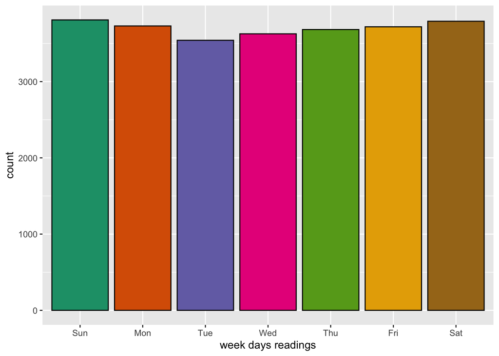

#### Average concentration of particles each week day

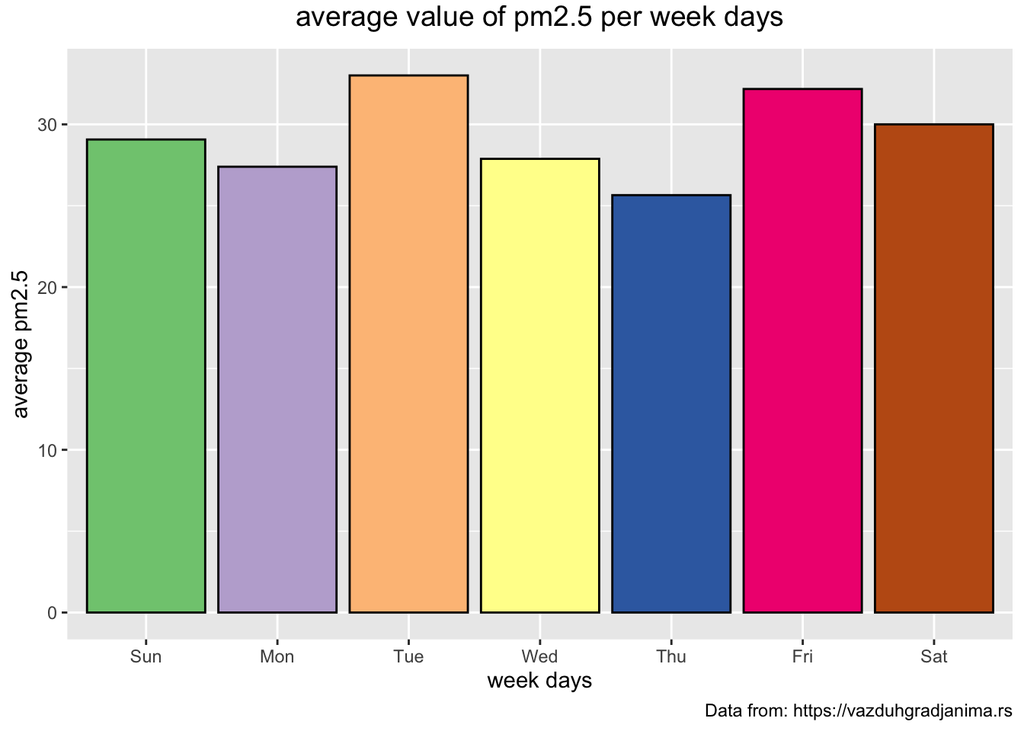

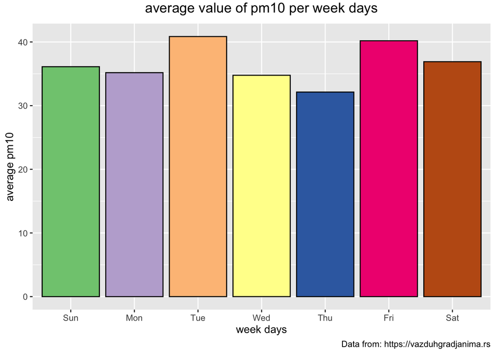

The previous two plots look very similar. It would be interesting to see the bars of the two plots next to each other.

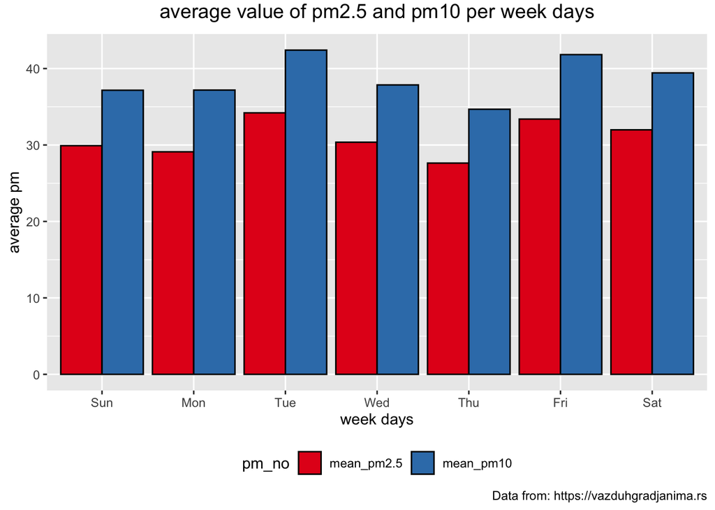

#### Average concentration of particles each month

|  | mon | no_readings |
| --- | --- | --- |
| 1 | Jan | 3935 |
| 2 | Oct | 3310 |
| 3 | Nov | 9342 |
| 4 | Dec | 9315 |

It would be better to have January showing after December, so we will reorder them.

|  | mon | no_readings |
| --- | --- | --- |
| 1 | Oct | 3310 |
| 2 | Nov | 9342 |
| 3 | Dec | 9315 |
| 4 | Jan | 3935 |

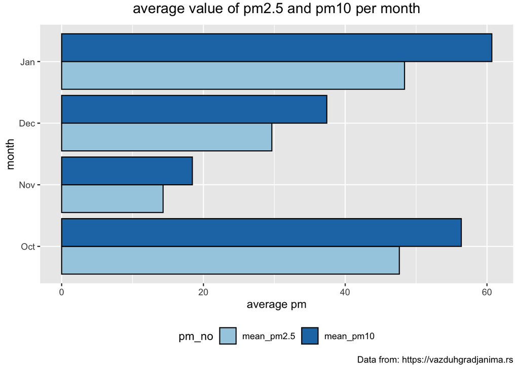

#### Average concentration of particles each hour

|  | time | no_readings |
| --- | --- | --- |
| 1 | 00:00:00 | 1064 |
| 2 | 01:00:00 | 1062 |
| 3 | 02:00:00 | 1062 |
| 4 | 03:00:00 | 1046 |
| 5 | 04:00:00 | 1045 |
| 6 | 05:00:00 | 1058 |
| 7 | 06:00:00 | 1072 |
| 8 | 07:00:00 | 1087 |
| 9 | 08:00:00 | 1098 |
| 10 | 09:00:00 | 1106 |

[output cut: 14 more lines]

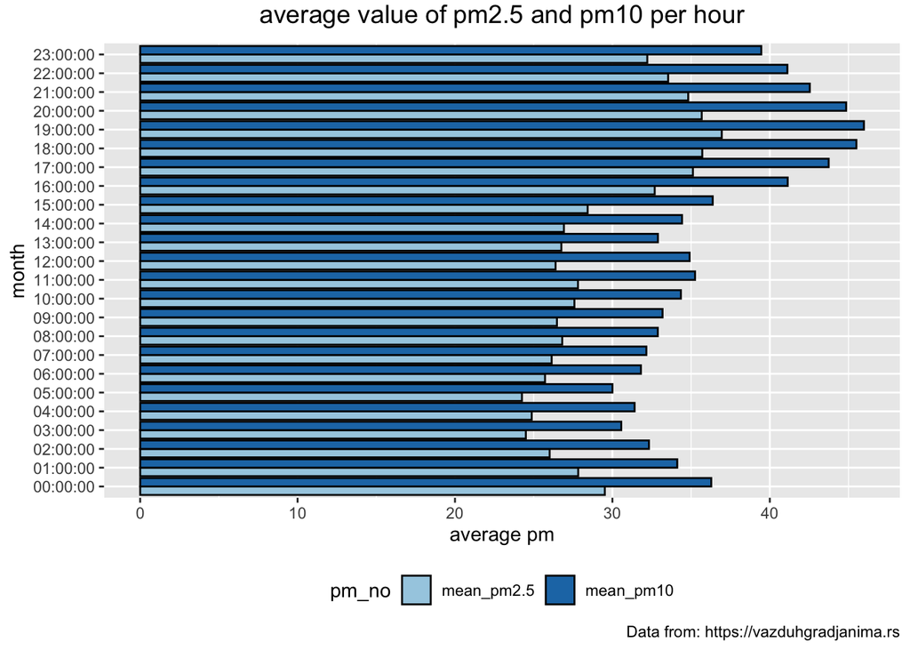

### Pressure and Humidity vs pm10

In this section we will try to investigate if the concentration of pm particles depens upon other factors such as pressure and humidity.

#### pm10 vs pressure

To investigate the relationship between air pressure and concentration of pm10 particles we will create a scatterplot:

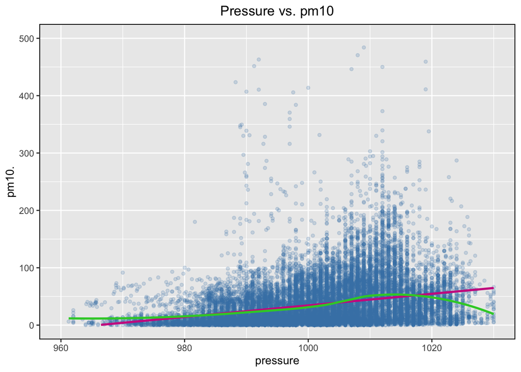

The data is quite messy, with a number of very extreme readings, which is why we “chopped” the axis using the `xlim()` and the `ylim()` functions after checking the distributions of the two variables. This is a part of informal investigation of the possible relationship between `pm10` and `pressure`, and a more rigorous procedure should be adopted which is beyond the scope of this workshop.

#### pm10 vs humidity

We will adopt the same approach to investigate a possible relationship between humidity and concentration of the pm10 particles.

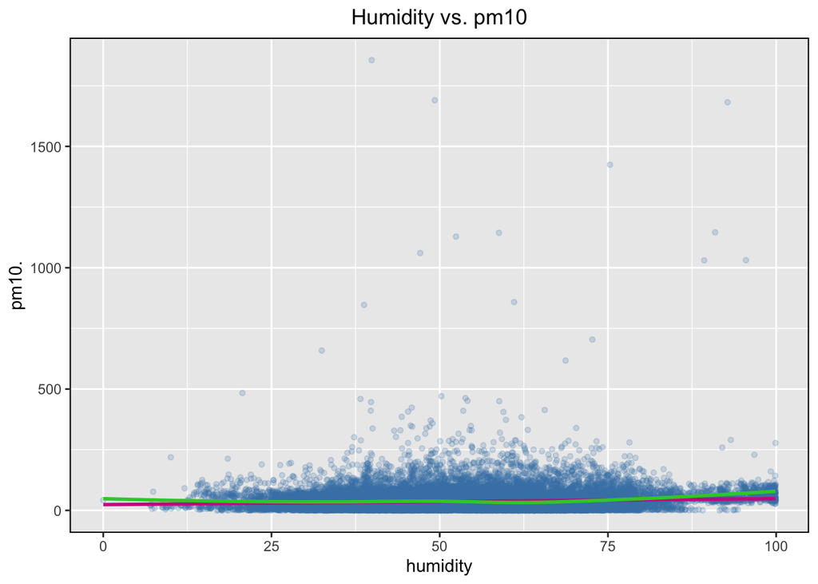

As a challenge try to use a scatterplot to investigate a possible relationship between the concentration of the `p10` particles and the `temperature`.

**Happy R coding!!!** 😃🙌💜